# Prácticas de aula 3 (PA03). Procesa datos GNSS y obtén soluciones fijas Geomorfología (GEO-114) Universidad Autónoma de Santo Domingo (UASD)

El Tali

2026-10-12

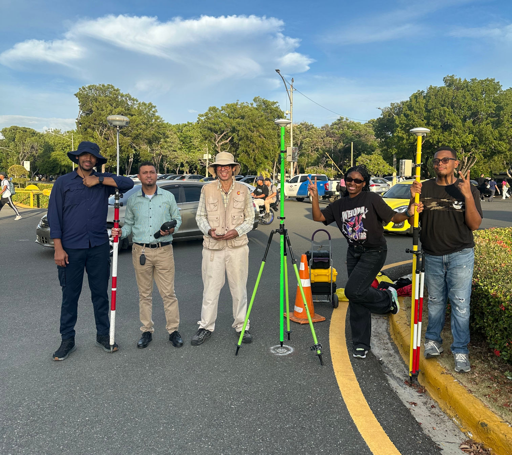

**Foto: José Gabriel Almánzar/Christian Gómez**. El trabajo de campo en el campus no es que sea “campo a través”, pero parece que pone a la gente contenta.

# Guía para solución

Consulta una guía para solución de la práctica [aquí](https://geomorfologia-master.github.io/datos-gnss-soluciones-fijas/ppk-guia-para-solucion.html). La guía incluye instrucciones paso a paso para procesar los datos y generar las soluciones fijas.

# Fecha/hora de entrega

**Ver portal de la asignatura**

# Objetivos

1. **Familiarizarse con un flujo reproducible de procesamiento GNSS**: convertir observaciones crudas a RINEX, preparar observaciones estáticas de una base, obtener de forma independiente una coordenada precisa mediante PPP y utilizarla posteriormente para PPK.
2. **Evaluar la calidad de datos GNSS crudos**: mediante inspección de los archivos RINEX y herramientas de RTKLIB-EX, identificar problemas como interrupciones, saltos de ciclo (*cycle slips*), geometría desfavorable o pérdida de observaciones.
3. **Comprender el papel del marco de referencia y de la época de las coordenadas**: interpretar correctamente una solución PPP expresada en ITRF/IGS y su época, y comprender por qué **no es necesario transformar dicha coordenada al WGS84 original (Transit) para realizar el PPK con RTKLIB-EX** cuando la coordenada PPP y las observaciones corresponden a la misma época y se emplean productos GNSS modernos.
4. **Obtener de manera independiente la coordenada precisa de la base**: cada estudiante preparará las observaciones estáticas de la base y enviará personalmente el RINEX resultante a un servicio PPP/posprocesamiento como CSRS-PPP de NRCan, OPUS o AUSPOS.
5. **Generar soluciones fijas mediante PPK**: procesar aproximadamente 120 segundos de observaciones tomadas en un mismo punto del campus con dos tipos de rover, Unicore (triple frecuencia) y u-blox (doble frecuencia), y comparar los resultados.
6. **Documentar el flujo mediante código reproducible**: aunque RTKLIB-EX dispone de interfaces gráficas, se priorizará el uso de `convbin`, `rnx2rtkp` y `gfzrnx` desde scripts ejecutables y documentados en este cuaderno.

# Recursos

- [**Carpeta de Drive con archivos fuente de la práctica (base y rovers)**](https://drive.google.com/drive/folders/1QwhfmtxwDR04yZ38Cwc9Fkcq6g_mmFg0?usp=drive_link)
- Software:
  - [RTKLIB-EX, antiguamente “Demo5”](https://github.com/rtklibexplorer/RTKLIB/releases). Usa la versión más reciente disponible. RTKLIB-EX proporciona tanto aplicaciones con interfaz gráfica como programas equivalentes para terminal: RTKCONV/`convbin` para conversión y RTKPOST/`rnx2rtkp` para posproceso.
  - [GFZRNX](https://gnss.gfz.de/services/gfzrnx), herramienta para comprobar, manipular, unir, dividir, seleccionar y diezmar archivos RINEX. Existen ejecutables para Windows y GNU/Linux. Si prefieres trabajar en un entorno Linux desde Windows, puedes usar WSL (*Windows Subsystem for Linux*).

> **Preferencia de esta práctica:** puedes utilizar RTKCONV y RTKPOST para explorar las opciones y comprobar visualmente configuraciones, pero el procesamiento que reportes debe quedar reproducible. Por ello, es preferible ejecutar `convbin`, `gfzrnx` y `rnx2rtkp` mediante scripts y conservar dichos scripts en tu repositorio.

# Datos y geometría de la práctica

Cada estudiante dispone de dos colectas cortas realizadas aproximadamente durante **120 segundos en el mismo punto del campus de la UASD**:

- una colecta con rover **Unicore**, receptor GNSS de triple frecuencia;
- una colecta con rover **u-blox**, receptor GNSS de doble frecuencia.

Durante la ocupación se utilizó un **jalón** de aluminio. Te facilitaré la altura empleada y la información necesaria de las antenas. Es importante distinguir:

- **ARP (*Antenna Reference Point*)**: punto físico de referencia de la antena respecto del cual se mide normalmente la altura instrumental o del jalón;
- **PCO (*Phase Center Offset*)**: vector que relaciona el ARP con el centro de fase medio de una señal/frecuencia;
- **APC (*Antenna Phase Center*)**: centro de fase efectivo, que depende de la señal y puede variar con la dirección de llegada de la señal.

Por tanto, **no debes inventar una corrección APC** ni restar automáticamente la longitud del jalón a una coordenada. Te proporcionaré la altura ARP–marca y, cuando corresponda, el tipo/modelo de antena o sus parámetros de calibración (PCO/PCV). Deberás declarar en tu informe qué punto representa finalmente tu solución: ARP o marca/punto del terreno.

# Ejercicio 1. Descarga tus datos, conviértelos, evalúa su calidad, descríbelos

- Descarga desde la [**carpeta de Drive con archivos fuente de la práctica (base y rovers)**](https://drive.google.com/drive/folders/1QwhfmtxwDR04yZ38Cwc9Fkcq6g_mmFg0?usp=drive_link) tus dos colectas de rover y los archivos horarios correspondientes a la base.
- Organiza el proyecto, por ejemplo (no está así estructurado en la carpeta de Drive, y esto es sólo una sugerencia, puedes organizar como prefieras, pero siguiendo un orden):

```
gnss/
├── raw/
│   ├── base/
│   └── rover/
├── rinex/
│   ├── base/
│   └── rover/
├── ppp/
├── ppk/
└── scripts/
```

## Convierte a RINEX

Convierte las observaciones crudas (*raw*) a **RINEX 3.04**. Los archivos crudos contienen observables GNSS (pseudorango, fase portadora, Doppler, SNR, etc.) y mensajes de navegación/efemérides transmitidas.

En esta práctica encontrarás dos familias de receptores:

- **Unicore UM980** (triple frecuencia): archivos extensión `.log`. La versión reciente de RTKLIB-EX utilizada en la asignatura permite convertir correctamente los archivos crudos Unicore (triple frecuencia) mediante RTKCONV o `convbin`. En versiones anteriores esta compatibilidad era incompleta, razón por la cual en prácticas antiguas se recurría al programa propietario Converter de Unicore.
- **u-blox ZED-F9P** (doble frecuencia): los archivos `.ubx` son compatibles con RTKLIB desde hace mucho tiempo y pueden convertirse mediante RTKCONV o `convbin`.

Para fines de comprobación, los detalles sobre hora exacta de colecta (hora GPS), persona que colectó y tipo de receptor) fueron facilitados vía el foro; transcribo dicha información a continuación:

GPS time

- Talibán
  - Triple: 15:03:10
  - Doble: 15:19:49
- Buanerges
  - Triple: 15:32:04
  - Doble 15:38:59
- Juancito
  - Triple 15:45: 36
  - Doble 16:00:12
- Rosamalia
  - Triple 16:07:16
  - Doble 16:13:13
- Yeral
  - Triple 16:19:29
  - Doble 16:27:58
- Camila
  - Triple 16:35:00
  - Doble 16:42:08

Puedes realizar una primera conversión con RTKCONV para familiarizarte con las opciones, pero debes dejar documentada una conversión reproducible con `convbin`.

Ejemplo general para u-blox:

```bash
convbin -r ubx -v 3.04 \
  -o rinex/rover/rover_ublox.obs \
  -n rinex/rover/rover_ublox.nav \
  raw/rover/rover_ublox.ubx
```

Para Unicore, consulta primero la ayuda de **la versión de RTKLIB-EX instalada**:

```bash
convbin -h
```

y usa el formato de entrada Unicore que reconozca esa versión. No copies mecánicamente una opción `-r` de versiones antiguas: documenta en el cuaderno el comando que realmente utilizaste y la versión de `convbin`.

> **Importante:** revisa el encabezado y algunas épocas del RINEX resultante. La conversión no debe considerarse correcta sólo porque el programa haya producido un archivo.

## Evalúa la calidad

- Realiza una inspección visual de los RINEX de la base y de ambos rovers.
- Comprueba fechas, horas, intervalo, constelaciones, tipos de observación y continuidad.
- Usa RTKPLOT u otra herramienta de RTKLIB-EX para inspeccionar disponibilidad de satélites, DOP, interrupciones y posibles *cycle slips*.
- Para los RINEX Unicore, presta atención a `SYS / # / OBS TYPES` y `SYS / PHASE SHIFT`. Si un servicio PPP emite advertencias relacionadas con *phase alignment*, no supongas automáticamente que el problema se corrige escribiendo ceros en `SYS / PHASE SHIFT`: documenta la advertencia y comprueba los observables realmente presentes.

# Ejercicio 2. Prepara las observaciones de la base y obtén TU solución PPP

## Une los archivos horarios de la base

La base fue registrada en archivos horarios. **Cada estudiante debe construir por sí mismo el RINEX continuo que enviará al servicio PPP**.

Usa `gfzrnx` para unir (*splice*) los RINEX horarios. El patrón exacto de nombres dependerá de los archivos descargados. Por ejemplo:

```bash
gfzrnx -finp "rinex/base/*.obs" \
  -fout ppp/base_unida_01s.obs
```

Si tu versión o sistema operativo trata los comodines de manera diferente, consulta:

```bash
gfzrnx -h
```

y documenta la sintaxis finalmente utilizada.

Después de unirlos, comprueba que el archivo resultante contiene una serie temporal continua y que las horas inicial y final son las esperadas.

## Reduce la cadencia a 30 segundos

Para el envío PPP no necesitamos conservar una observación por segundo. Genera una copia a **30 s**. GFZRNX puede realizar el remuestreo:

```bash
gfzrnx -finp ppp/base_unida_01s.obs \
  -fout ppp/base_unida_30s.obs \
  -smp 30
```

También puedes realizar el diezmado con `convbin` leyendo el RINEX y usando `-ti 30`. Por ejemplo:

```bash
convbin -r rinex -v 3.04 -ti 30 \
  -o ppp/base_unida_30s_convbin.obs \
  ppp/base_unida_01s.obs
```

No es obligatorio aplicar **ambos** procedimientos. Elige uno, pero debes demostrar de manera reproducible que el archivo enviado tiene una cadencia de 30 s.

### Comprobaciones reproducibles

Puedes complementar `gfzrnx` con comandos del sistema (`ls`, `wc`, `grep`, etc.) y mostrar sus salidas en el cuaderno.

## Obtén una solución independiente para la coordenada de la base

**Cada estudiante deberá enviar personalmente su RINEX de 30 s a uno de estos servicios y conservar el informe de salida:**

- CSRS-PPP, Natural Resources Canada (NRCan);
- OPUS, National Geodetic Survey (NGS/NOAA);
- AUSPOS, Geoscience Australia.

El servicio elegido puede imponer requisitos particulares de duración, constelaciones, tipo de antena o formato. Debes revisar dichos requisitos antes del envío.

Registra en el informe:

- servicio utilizado;
- archivo RINEX enviado;
- intervalo de observación;
- duración total;
- modo de procesamiento;
- marco de referencia de la solución;
- **época de la coordenada**;
- coordenadas LLH y/o XYZ;
- incertidumbres reportadas;
- tratamiento de la antena y de la altura instrumental;
- advertencias emitidas por el servicio.

> **No uses una coordenada PPP facilitada por otra persona.** El objetivo es que cada estudiante complete y documente todo el flujo desde los archivos horarios hasta una solución PPP propia.

## Marco de referencia: no transformes la solución a WGS84 (Transit)

En versiones anteriores de esta práctica se pedía transformar la coordenada ITRF obtenida mediante PPP a **WGS84 original (Transit)** usando HTDP. **No hagas esa transformación.**

Una solución PPP moderna puede estar expresada, por ejemplo, en **ITRF2020/IGS20 a la época de las observaciones**. ITRF es un marco dinámico: no basta con conocer el nombre del marco, también importa la época de la coordenada.

RTKLIB-EX utiliza coordenadas cartesianas/geodésicas y los marcos implícitos en las órbitas empleadas, pero no necesita que una coordenada PPP moderna y coherente con la época de observación sea artificialmente transformada al WGS84 original (Transit). En esta práctica:

- la coordenada PPP de la base debe corresponder a la época de las observaciones;
- base y rover se observaron en la misma campaña;
- para PPK con efemérides transmitidas (*broadcast*) se utilizará directamente la coordenada PPP moderna de la base;
- si posteriormente se usan productos precisos SP3/CLK modernos, éstos se encuentran alineados con realizaciones IGS/ITRF modernas, lo que refuerza la necesidad de **conservar y documentar el marco y la época**, no de convertir a WGS84 Transit.

Por tanto, en tu informe escribe explícitamente algo como:

> *La coordenada de la base se obtuvo mediante PPP en [marco] a la época [época]. Se utilizó directamente como coordenada fija de la base en el PPK; no se realizó una transformación a WGS84 (Transit).*

# Ejercicio 3. Genera soluciones fijas PPK y evalúa el resultado

## Prepara la configuración reproducible de RTKLIB-EX

Puedes explorar la configuración mediante RTKPOST, pero el procesamiento final debe poder repetirse con `rnx2rtkp`.

Una forma cómoda de trabajar consiste en configurar RTKPOST, guardar la configuración y reutilizar ese archivo con `rnx2rtkp`. Conserva el archivo de configuración en tu repositorio, por ejemplo:

```
scripts/ppk.conf
```

Documenta, como mínimo:

- modo de posicionamiento;
- frecuencias utilizadas;
- constelaciones;
- máscara de elevación;
- estrategia de resolución de ambigüedades;
- modelo ionosférico y troposférico;
- efemérides empleadas (`broadcast` o precisas, si posteriormente repites el ejercicio);
- coordenada fija de la base, con marco y época;
- información de antena;
- altura ARP–marca o corrección aplicada;
- formato de salida.

## Antena, ARP, PCO/APC y jalón

La altura del jalón **no debe tratarse como una corrección genérica de 2 m**. Usa la altura que se te proporcione para esta campaña y deja claro entre qué puntos fue medida.

Para el rover, la observación GNSS está físicamente relacionada con el centro de fase de la antena, mientras que el punto que normalmente interesa levantar está en la base del jalón. RTKLIB puede aplicar correcciones de antena cuando dispone de la información apropiada. Te facilitaré el modelo de antena y/o los parámetros necesarios.

En el informe distingue:

- punto del terreno o marca;
- ARP;
- altura ARP–marca;
- PCO/PCV cuando se suministren;
- punto al cual corresponde la coordenada final reportada.

## Genera las soluciones

Tienes dos rovers observados aproximadamente durante 120 s en el mismo punto:

1. rover **u-blox**;
2. rover **Unicore**.

Ambos se procesarán respecto de **la misma base cuya coordenada obtuviste personalmente mediante PPP**.

Un comando reproducible tendrá esta estructura general:

```bash
rnx2rtkp -k scripts/ppk.conf \
  -o ppk/rover_ublox.pos \
  rinex/rover/rover_ublox.obs \
  rinex/base/base_correspondiente.obs \
  rinex/base/base.nav
```

y para Unicore:

```bash
rnx2rtkp -k scripts/ppk.conf \
  -o ppk/rover_unicore.pos \
  rinex/rover/rover_unicore.obs \
  rinex/base/base_correspondiente.obs \
  rinex/base/base.nav
```

Adapta los nombres y los archivos de navegación a los que realmente generaste. Si las observaciones cruzan un cambio de día, asegúrate de incluir todos los archivos de navegación necesarios.

**Para cada rover realiza dos salidas:**

- una solución que te permita obtener/resumir la posición fija del punto;
- una salida época por época para estudiar dispersión, estado FIX/FLOAT y estabilidad.

En total tendrás, como mínimo, **cuatro productos de solución**: dos correspondientes al rover u-blox y dos al rover Unicore.

> No basta con presentar archivos `.pos`. Debes incluir el script o los comandos que permitan regenerarlos a partir de los RINEX y del archivo de configuración.

## Representa tabular y cartográficamente, compara

### Representación tabular

Muestra los resultados de las soluciones promediadas en una tabla como ésta:

| Rover | Receptor | Resultado (LLH o XYZ) | % FIX | Observaciones |
| --- | --- | --- | --- | --- |
| u-blox | doble frecuencia |  |  |  |
| Unicore | triple frecuencia |  |  |  |

Incluye también la coordenada PPP utilizada para la base, indicando **marco y época**, pero no la mezcles con las coordenadas rover como si todas fueran observaciones equivalentes.

Para graficar las soluciones, ve a tu cuenta en el servidor RStudio, sube tus archivos de soluciones `.pos`, carga la función personalizada `pos_read_violin` usando el comando siguiente:

```r
devtools::source_url(
paste0('https://raw.githubusercontent.com/geomorfologia-master/',
       'datos-gnss-soluciones-fijas/refs/heads/main/R/funciones.R'))
```

Evalúa la función:

```r
archivos_pos <- list.files(pattern = '*.pos')
res <- pos_read_violin(archivos_pos, q_filter=1, export='gpkg',
                       export_path = "ppk_fix.gpkg",
                       export_layer = "ppk_fix",
                       plot_stat = "raw", stat_by = "archivo")
```

e imprime el resultado:

```r
res
```

Si notas mucha dispersión, o quieres comparar la dispersión respecto de la media:

```r
res <- pos_read_violin(archivos_pos, q_filter=1, export='gpkg',
                       export_path = "ppk_fix.gpkg",
                       export_layer = "ppk_fix",
                       plot_stat = "z", stat_by = "archivo")
res
```

El argumento `export='gpkg'` genera un archivo GeoPackage (`ppk_fix.gpkg`) que puedes descargar y abrir en QGIS. El argumento `export_layer` permite definir el nombre de la capa.

### Compara los resultados

Compara las soluciones época por época de los dos receptores. Como ambos levantaron el mismo punto, interesa cuantificar:

- diferencia entre las coordenadas promediadas;
- dispersión de cada solución;
- porcentaje de épocas FIX;
- presencia de FLOAT, SINGLE, outliers o interrupciones;
- diferencias horizontales y verticales;
- posible efecto de utilizar receptor doble frecuencia frente a triple frecuencia.

Si las dos colectas **no son temporalmente coincidentes**, no las trates como muestras emparejadas. Puedes usar una prueba t de Student no emparejada por componente, siempre que discutas sus supuestos y limitaciones. Si el objetivo principal es comparar precisión/estabilidad, acompaña cualquier prueba inferencial con medidas descriptivas de dispersión y diferencias en metros.

| Componente | Media u-blox | Media Unicore | Diferencia | p | Interpretación |
| --- | --- | --- | --- | --- | --- |
| Lat / X |  |  |  |  |  |
| Lon / Y |  |  |  |  |  |
| H / Z |  |  |  |  |  |

### Representación cartográfica

Representa las soluciones promediadas y/o época por época en RTKPLOT o QGIS. La simbología debe permitir distinguir claramente las soluciones del rover u-blox y del rover Unicore.

Cuando la separación sea muy pequeña para apreciarse a escala cartográfica, complementa el mapa con gráficos en coordenadas locales E/N/U o con distancias respecto de una posición de referencia.

# Redacta un informe integrado (IMRaD abreviado)

Prepara un **informe breve con estructura IMRaD** (Introducción, Métodos, Resultados, Discusión), **usando IA como apoyo si lo deseas**. Todo debe ser conciso: **cada sección debe tener entre 3 y 4 párrafos cortos**. Añade lista de referencias al final y citas en el texto (mínimo **3** fuentes).

> **Uso de IA**: puedes apoyarte en herramientas de IA para redactar, resumir, programar o formatear, pero debes verificar contenidos, números, comandos y citas. Añade al final una breve nota explicando para qué utilizaste IA y qué verificaciones realizaste.

## 1) Introducción (3–4 párrafos)

- **Contexto y relevancia**: posicionamiento GNSS, PPP, PPK/RTK y aplicaciones en geomorfología.
- **Estado breve del arte**: diferencia entre PPP y posicionamiento relativo; observables de fase; importancia de RINEX, marco de referencia y época.
- **Objetivo(s) y pregunta(s)**: compara las soluciones obtenidas con rover u-blox y rover Unicore en el mismo punto.
- **Hipótesis (opcional)**: plantea si esperas diferencias de dispersión o porcentaje FIX entre receptor doble y triple frecuencia y justifica por qué.

- **Tabla(s) y figura(s) numeradas**: incluye al menos una tabla de coordenadas/resúmenes y una o dos figuras.
- **PPP de la base**: informa coordenada, marco, época e incertidumbre obtenidos por tu propio envío.
- **PPK**: reporta coordenadas de ambos rovers, porcentaje FIX, dispersión y diferencias entre soluciones.
- **Calidad y anomalías**: documenta *cycle slips*, interrupciones, advertencias de conversión/PPP, FLOAT, outliers u otras incidencias.

## 4) Discusión (3–4 párrafos)

- **Interpretación**: explica las diferencias entre los dos receptores y separa precisión relativa, exactitud absoluta y dispersión.
- **Marco de referencia**: discute por qué conservar el ITRF/IGS moderno y su época es preferible a transformar innecesariamente la solución a WGS84 (Transit).
- **Limitaciones**: ocupaciones rover de sólo ~120 s, multipath del campus, geometría satelital, configuración de RTKLIB-EX, calidad de la coordenada PPP y tratamiento de antena.
- **Implicaciones y trabajo futuro**: sesiones más largas, productos SP3/CLK Rapid/Final, repetición en distintos entornos, comparación entre efemérides broadcast y precisas.

## Referencias

- Incluye **mínimo 3** fuentes y cítalas en el texto.
- Sugerencias:
  - documentación de **RTKLIB-EX/RTKLIB**;
  - documentación del servicio PPP utilizado (NRCan/CSRS-PPP, OPUS o AUSPOS);
  - documentación de **GFZRNX**;
  - especificación **RINEX**;
  - literatura científica sobre PPP, RTK/PPK, resolución de ambigüedades y marcos ITRF/IGS.

### Requisitos de forma

- **Extensión breve**: 4 secciones × **3–4 párrafos** cada una.
- **Reproducibilidad obligatoria**: incluye los comandos/scripts utilizados para conversión, unión, diezmado y PPK.
- **Trazabilidad PPP**: adjunta o conserva el informe del servicio y registra marco, época e incertidumbres.
- **Antena**: documenta ARP, altura ARP–marca y los parámetros PCO/PCV suministrados.
- **Numeración de figuras y tablas**, mención en el texto y leyendas claras.
- **Transparencia sobre IA**: identifica qué tareas se apoyaron en IA y qué errores o limitaciones detectaste al verificar sus respuestas.
- **Entregable**: PDF/HTML, con tablas/figuras incrustadas, scripts reproducibles y lista de referencias.